# Block-Level Greenness and Housing Density Change, 2010–2020

Lilac Hong

2026-04-28

## Research question

**Is housing development adversely affecting exposure to green environments?**

We address this using the pseudo-residual change framework from Lambert et al. (2025), which asks: *given how much a block’s housing density changed between 2010 and 2020, did its greenness change more or less than expected?*

## Methods

### Analytical framework

We regress 2010 NDVI on log(housing unit density) to establish a baseline greenness–housing relationship. The 2010 residual is the **greenness:housing index** (GHI) — positive means greener than expected for a block’s density (“Bright”), negative means less green (“Dim”). We then apply the *same 2010 coefficients* to 2020 housing density to generate expected 2020 NDVI, and compute a 2020 pseudo-residual. The change ΔGHI = GHI<sub>2020</sub> − GHI<sub>2010</sub> captures whether a block **brightened** (became greener than expected) or **dimmed** (became less green than expected) after accounting for its housing density trajectory.

### Baseline regressions (2010)

For each retained scenario we fit:

$$\text{NDVI}_{2010} = \alpha + \beta
\cdot \log(\text{HU\_density}_{2010})$$

Housing unit densities of zero were replaced with a small positive value (1 × 10<sup>−10</sup>) prior to log transformation. After scenario comparison (see supplemental `1_1_block_ndvi_scenario_comparison`), we retained **4 of 6 scenarios**: Dormant × 1000 m, and Growing × {500, 1000, 2000 m}. Season differences are large (Cohen’s d > 1); dormant-season buffer differences are negligible; growing-season buffers are retained for sensitivity.

**Important caveat on baseline R².** The 2010 R² is ≤ 0.031 in every scenario — housing density alone explains very little of the spatial variation in NDVI at the block level. This means the pseudo-residual is dominated by factors *other* than housing (biophysical setting, canopy composition, land-use history). The framework is still useful because it adjusts for the *expected* greenness shift due to densification, but readers should understand that ΔGHI is close to raw ΔNDVI. The housing-density adjustment matters most for blocks that densified substantially.

### Table 1: 2010 regression coefficients

Table 1: 2010 OLS regression of NDVI on log(HU density)

| season | buffer | intercept | slope | slope_se | slope_p | R2 | n |
| --- | --- | --- | --- | --- | --- | --- | --- |
| Dormant_Season | 1000 | 0.4999 | 0.001485 | 4.2e-05 | 0.0000 | 0.0150 | 82986 |
| Growing_Season | 500 | 0.5894 | 0.001776 | 4.6e-05 | 0.0000 | 0.0177 | 82783 |
| Growing_Season | 1000 | 0.5905 | 0.000986 | 4.3e-05 | 0.0000 | 0.0064 | 83056 |
| Growing_Season | 2000 | 0.5918 | -0.000094 | 3.9e-05 | 0.0154 | 0.0001 | 83253 |

Slopes are small and positive (dormant) or near-zero (growing at 2000 m). R² is ≤ 0.031 everywhere — the baseline relationship is weak at the block level.

### Residuals, pseudo-residuals, and change

- GHI<sub>2010</sub> = NDVI<sub>2010</sub> − (α̂ + β̂ · log(HU_density<sub>2010</sub>))
- GHI<sub>2020</sub> = NDVI<sub>2020</sub> − (α̂ + β̂ · log(HU_density<sub>2020</sub>))
- **ΔGHI = GHI<sub>2020</sub> − GHI<sub>2010</sub>**

Positive ΔGHI = **brightening** (greener than expected given housing trajectory). Negative = **dimming**.

There are six possible transition × direction combinations:

| GHI<sub>2010</sub> | GHI<sub>2020</sub> | ΔGHI | Interpretation |
| --- | --- | --- | --- |
| + (Bright) | + (Bright) | + (Brightened) | More bright |
| + (Bright) | + (Bright) | − (Dimmed) | Still bright but declining |
| + (Bright) | − (Dim) | − (Dimmed) | Worst case |
| − (Dim) | + (Bright) | + (Brightened) | Best case |
| − (Dim) | − (Dim) | + (Brightened) | Less dim |
| − (Dim) | − (Dim) | − (Dimmed) | More dim |

## Results

### Statistical comparisons across season and buffer

#### Paired t-test: Dormant vs. Growing at 1000 m

```
##
##  Paired t-test
##
## data:  paired$Dormant_Season and paired$Growing_Season
## t = -237.24, df = 82979, p-value < 2.2e-16
## alternative hypothesis: true mean difference is not equal to 0
## 95 percent confidence interval:
##  -0.08941854 -0.08795316
## sample estimates:
## mean difference
##     -0.08868585
```

The paired t-test is highly significant (p < 2.2 × 10<sup>−16</sup>), confirming that dormant and growing seasons tell fundamentally different stories about greenness change.

#### ANOVA and Tukey HSD: buffer within Growing Season

```
##                 Df Sum Sq  Mean Sq F value Pr(>F)
## buffer_f         2   0.01 0.002907   3.057  0.047 *
## Residuals   249089 236.87 0.000951
## ---
## Signif. codes:  0 '***' 0.001 '**' 0.01 '*' 0.05 '.' 0.1 ' ' 1
```

```
##
## Tukey HSD pairwise buffer comparisons (Growing Season):
```

```
##   Tukey multiple comparisons of means
##     95% family-wise confidence level
##
## Fit: aov(formula = change_green ~ buffer_f, data = grow)
##
## $buffer_f
##                   diff           lwr          upr     p adj
## 1000-500  0.0001261784 -2.287743e-04 0.0004811311 0.6824060
## 2000-500  0.0003681134  1.337037e-05 0.0007228564 0.0398222
## 2000-1000 0.0002419350 -1.125155e-04 0.0005963856 0.2457275
```

#### Cross-buffer ΔGHI correlation (Growing Season)

Cross-buffer correlation of ΔGHI (Growing Season)

|  | b500 | b1000 | b2000 |
| --- | --- | --- | --- |
| b500 | 1.0000 | 0.8144 | 0.5498 |
| b1000 | 0.8144 | 1.0000 | 0.7963 |
| b2000 | 0.5498 | 0.7963 | 1.0000 |

### Change variable summaries (Table 2)

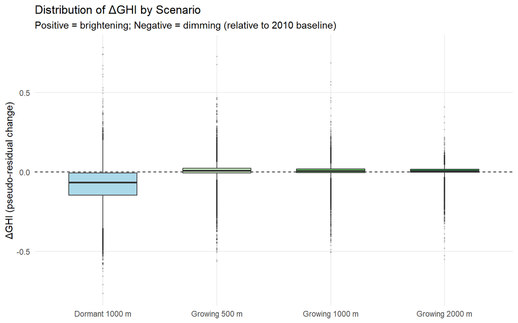

Table 2: Greenness change summary by scenario

| season | buffer | n | mean_change_green | sd_change_green | median_change_green | pct_brightened_green | pct_dimmed_green |
| --- | --- | --- | --- | --- | --- | --- | --- |
| Dormant_Season | 1000 | 82986 | -0.08301 | 0.10496 | -0.06538 | 22.0 | 78.0 |
| Growing_Season | 500 | 82783 | 0.00552 | 0.03750 | 0.00767 | 64.6 | 35.4 |
| Growing_Season | 1000 | 83056 | 0.00565 | 0.03000 | 0.00706 | 66.0 | 34.0 |
| Growing_Season | 2000 | 83253 | 0.00589 | 0.02344 | 0.00710 | 68.5 | 31.5 |

The dormant season shows strong net dimming (mean ΔGHI ≈ −0.083; only ~22% of blocks brighten). The growing season shows mild net brightening (mean ΔGHI ≈ +0.006; ~65–68% brighten). This means that **structural/evergreen cover declined** (dormant dimming) while **active-season canopy held or slightly improved** (growing brightening).

### Bright/Dim transitions (Table 3)

Table 3: Greenness Bright/Dim transitions (2010 → 2020)

| season | buffer | Bright -> Bright | Bright -> Dim | Dim -> Bright | Dim -> Dim |
| --- | --- | --- | --- | --- | --- |
| Dormant_Season | 1000 | 21417 | 20106 | 2674 | 38789 |
| Growing_Season | 500 | 40083 | 1893 | 3695 | 37112 |
| Growing_Season | 1000 | 40525 | 1385 | 2914 | 38232 |
| Growing_Season | 2000 | 41226 | 1306 | 2619 | 38102 |

### Does densification predict dimming? (Table 4)

This is the central test for the research question. We regress ΔGHI on Δlog(HU density) within each scenario. A **negative slope** means blocks that densified more also dimmed more — i.e., housing development is associated with disproportionate greenness loss.

Table 4: ΔGHI ~ Δlog(HU density) regression by scenario

| scenario | n | slope | se | p | R2 |
| --- | --- | --- | --- | --- | --- |
| Dormant 1000 m | 82986 | -0.001579 | 7.6e-05 | 0 | 0.005119 |
| Growing 500 m | 82783 | -0.002346 | 2.6e-05 | 0 | 0.088766 |
| Growing 1000 m | 83056 | -0.001340 | 2.1e-05 | 0 | 0.045107 |
| Growing 2000 m | 83253 | -0.000103 | 1.7e-05 | 0 | 0.000440 |

**All four slopes are negative and highly significant (p < 10<sup>−9</sup>).** Blocks that densified more experienced greater greenness loss than expected. The effect is strongest in the growing season at 500 m (slope = −0.0023, R² = 0.089), meaning that a one-unit increase in log housing density is associated with a 0.0023-unit decline in the greenness index. The dormant-season effect is smaller (slope = −0.0016, R² = 0.005) but still significant.

The R² values are small (0.04%–8.9%), which means densification explains only a modest fraction of the variation in ΔGHI. Many blocks dimmed or brightened for reasons unrelated to housing. But the direction is unambiguous: **on average, densification is associated with disproportionate greenness loss.**

### Visualizing the densification–greenness link

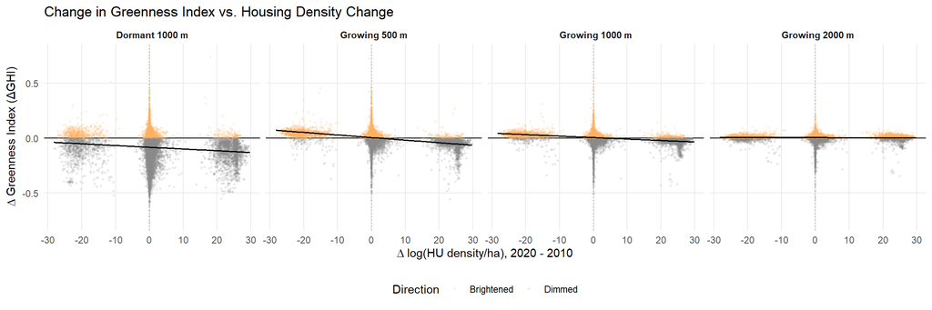

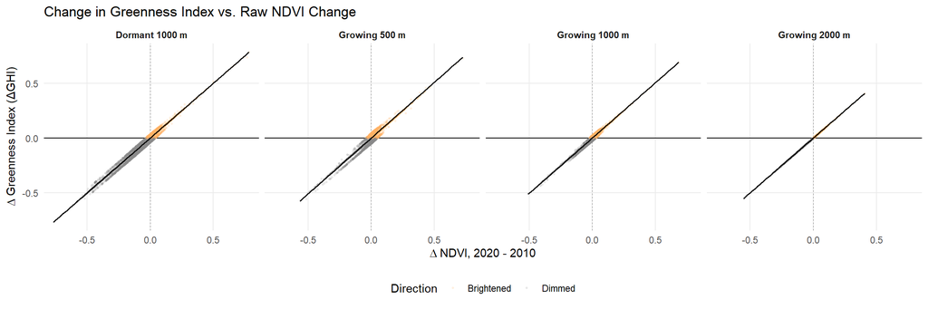

### Connecting transitions to densification (Table 5)

To test whether blocks that densified the most were disproportionately likely to lose their “Bright” status, we split blocks into densification quartiles (Q1 = least densification, Q4 = most) and compute the rate of Bright → Dim transitions among blocks that started Bright in 2010.

Table 5: P(Bright → Dim) by densification quartile, among blocks Bright in 2010

| scenario | dens_q | n_bright_2010 | n_went_dim | pct_went_dim |
| --- | --- | --- | --- | --- |
| Dormant 1000 m | Q1 (least) | 10382 | 4525 | 43.6 |
| Dormant 1000 m | Q2 | 16746 | 8436 | 50.4 |
| Dormant 1000 m | Q3 | 4015 | 2117 | 52.7 |
| Dormant 1000 m | Q4 (most) | 10380 | 5028 | 48.4 |
| Growing 500 m | Q1 (least) | 10501 | 279 | 2.7 |
| Growing 500 m | Q2 | 16823 | 755 | 4.5 |
| Growing 500 m | Q3 | 4158 | 104 | 2.5 |
| Growing 500 m | Q4 (most) | 10494 | 755 | 7.2 |
| Growing 1000 m | Q1 (least) | 10493 | 228 | 2.2 |
| Growing 1000 m | Q2 | 16928 | 676 | 4.0 |
| Growing 1000 m | Q3 | 4011 | 83 | 2.1 |
| Growing 1000 m | Q4 (most) | 10478 | 398 | 3.8 |
| Growing 2000 m | Q1 (least) | 10634 | 223 | 2.1 |
| Growing 2000 m | Q2 | 17327 | 719 | 4.1 |
| Growing 2000 m | Q3 | 3938 | 82 | 2.1 |
| Growing 2000 m | Q4 (most) | 10633 | 282 | 2.7 |

**Dormant season:** The Bright → Dim rate is high across all quartiles (44–53%), reflecting the pervasive dormant dimming. The rate is slightly higher in Q2–Q3 than Q1 or Q4, suggesting a modest but non-monotonic relationship with densification.

## Discussion

### Does housing development adversely affect greenness?

**Yes, but the answer depends on what you measure and when.**

### Limitations

- **Low baseline R².** The pseudo-residual framework adjusts for the expected greenness–housing relationship, but that relationship is weak at the block level (R² ≤ 0.03). ΔGHI is therefore close to raw ΔNDVI. The framework adds most value for blocks with large housing density changes.
- **Observational design.** The negative slope of ΔGHI on Δlog(HU density) is an association, not a causal estimate. Blocks that densified may differ from those that did not in ways that independently affect greenness (e.g., proximity to urban cores, zoning, pre-existing land cover).
- **Temporal resolution.** Two time points (2010, 2020) cannot distinguish between gradual change and abrupt events (e.g., a wildfire followed by recovery).

## References

Lambert, M. R., Des Roches, S., Auerbach, D. A., Van Deynze, B., Behrens, S., Hale, R., & Pierce, K. B. (2025). Building the neighborhood for the trees: Illuminating win–wins for housing densification and nature. *Conservation Science and Practice*, 7(7), e70085.